# Black Friday Clustering

# Problem Statement.

We are unsure on how the suppliers performed over Black Friday for Retailer 1. It would be useful to see how they performed to understand how much Retailer 1 is benefitting from these suppliers.

# Suggested solution.

# 1. Overview

This notebook uses DBSCAN clustering to group suppliers for Retailer 1 based on the quantity of sales vs the average value of their sales.

# 2. Load libraries

DBSCAN and Tidyverse’s collection of libraries includes all of the packages required to complete this analysis.

```r
#install.packages("tidyverse")
#install.packages("dbscan")
library(dbscan)
library(tidyverse)
```

# 3. Load data

Import the CSV file for Retailer 1 into R, and use ‘head’ to preview the new data.

```r
BFdata <- read.csv('BF Clusterings.csv')
head(BFdata)
```

```
    Supplier Average.Cost.... Count.of.Orders
1 Supplier 1        324.99000               2
2 Supplier 2         70.75471             119
3 Supplier 3        103.39000               5
4 Supplier 4        233.32333               3
5 Supplier 5         87.15172             373
6 Supplier 6        137.69400              10
```

# 4. Explore and transform the data

Looking at the data it is clear to see that the column headers can be renamed to make it easier for 3rd parties to understand the data.

```r
# The column headers are confusing due to the symbols I will rename them to replace the '.' with a space.
names(BFdata) <- c("Supplier", "Average Order Cost (£)", "Count of Orders")
# I will check the the changes have worked as expected.
head(BFdata)
```

```
    Supplier Average Order Cost (£) Count of Orders
1 Supplier 1              324.99000               2
2 Supplier 2               70.75471             119
3 Supplier 3              103.39000               5
4 Supplier 4              233.32333               3
5 Supplier 5               87.15172             373
6 Supplier 6              137.69400              10
```

# 5. Visualise the data

Now that my data is in the format I want, I can visualise this data in a scatter plot. This will give me a good chance to eyeball the data and get an idea of what I might expect to see from the final result.

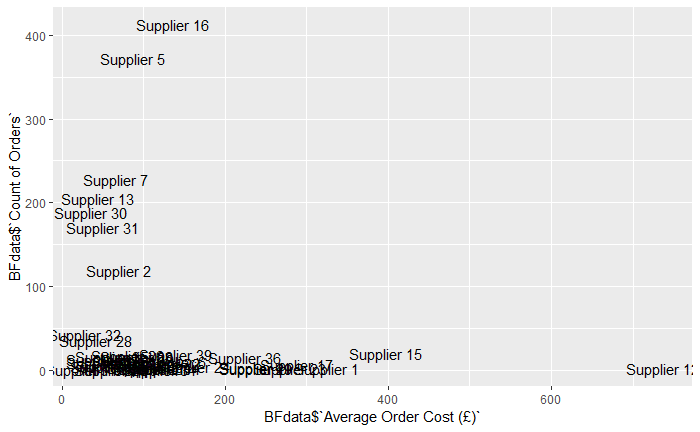

```r
qplot(x = BFdata$`Average Order Cost (£)`, y = BFdata$`Count of Orders`, label = BFdata$Supplier, geom = "text")
```

# 6. Clustering using DBSCAN and LOF (Local Outlier Factor)

I will use DBSCAN to cluster the Black Friday data. Useful resources: [How DBSCAN works -](https://towardsdatascience.com/how-dbscan-works-and-why-should-i-use-it-443b4a191c80) [How LOF works -](https://towardsdatascience.com/local-outlier-factor-for-anomaly-detection-cc0c770d2ebe) [Source for DBSCAN and LOF code -](https://github.com/mhahsler/dbscan)

I will start by using DBSCAN to see the cluster in this data set.

```r
x <- as.matrix(BFdata[, 2:3])
db <- dbscan(x, eps = 50, minPts = 1)
db
```

```
DBSCAN clustering for 39 objects.
Parameters: eps = 50, minPts = 1
The clustering contains 8 cluster(s) and 0 noise points.

 1  2  3  4  5  6  7  8
 6  1 24  1  4  1  1  1

Available fields: cluster, eps, minPts
```

Now I can use a scatter plot to visualise these clusters.

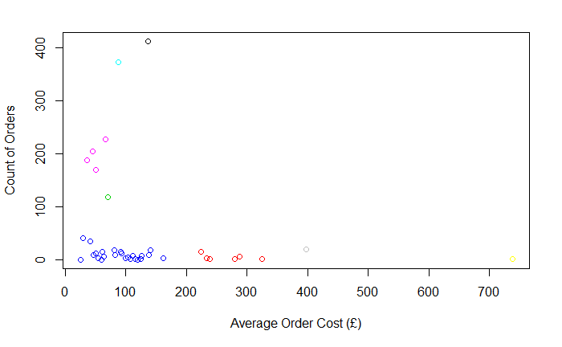

```r
plot(x, col = db$cluster + 1L)
```

I can also visualise this using ‘pairs’ to clearly show the 2 variables

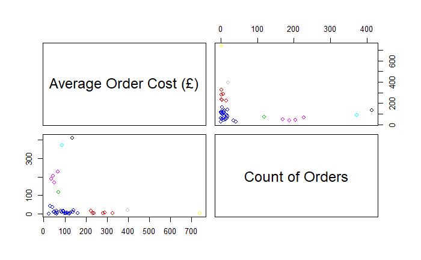

```r
pairs(x, col = db$cluster + 1L)
```

LOF can be used to show outliers in this data set. (Probably more useful in larger data sets)

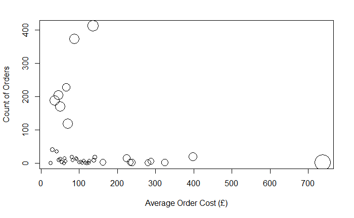

```r
lof <- lof(x, k = 8)
plot(x, cex = lof)
```

# 7. Use HDBSCAN to heirachically cluster the data set.

First, cluster the groups using the hdbscan function.

```r
hdb <- hdbscan(x, minPts = 2)
hdb
```

```
HDBSCAN clustering for 39 objects.
Parameters: minPts = 2
The clustering contains 12 cluster(s) and 5 noise points.

 0  1  2  3  4  5  6  7  8  9 10 11 12
 5  2  5  2  2  3  2  2  3  5  2  3  3

Available fields: cluster, minPts, cluster_scores, membership_prob, outlier_scores, hc
```

Now I can visualise this using plot.

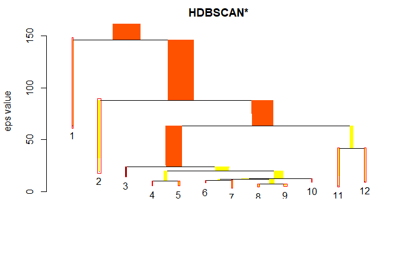

```r
plot(hdb, show_flat = T, gradient = c("yellow", "orange", "red", "blue"))
```